# The Game is Afoot & Poems of Mihai Eminescu

Jessica Randall

9/4/2020

This notebook follow’s Julia Silge’s topic modeling tutorial [video](https://youtu.be/evTuL-RcRpc) and [blog post](https://juliasilge.com/blog/sherlock-holmes-stm/) and expands on it with an example of topic modeling using Mihai Eminescu’s collection “Poems” in the original Romanian.

Additional Resources: [Tidy Text Mining](https://www.tidytextmining.com/tidytext.html) [Supervised Machine Learning for Text Analysis in R](https://smltar.com)

### Data prep

```r
sherlock <- sherlock_raw %>%
  mutate(story = ifelse(str_detect(text, "ADVENTURE"),
    text,
    NA
  )) %>%
  fill(story) %>%
  filter(story != "THE ADVENTURES OF SHERLOCK HOLMES") %>%
  mutate(story = factor(story, levels = unique(story)))

tidy_sherlock <- sherlock %>%
  mutate(line = row_number()) %>%
  unnest_tokens(word, text) %>%
  anti_join(stop_words) %>%
  filter(word != "holmes")

tidy_sherlock %>%
  count(word, sort = TRUE)
```

```
## # A tibble: 7,437 x 2
##    word        n
##    <chr>   <int>
##  1 time      151
##  2 door      144
##  3 matter    125
##  4 house     123
##  5 hand      120
##  6 night     114
##  7 heard     113
##  8 found     108
##  9 day       106
## 10 morning   102
## # ... with 7,427 more rows
```

### Explore tf-idf

Which words are most important in each story?

tf-idf: “identifies words that are important to a document in a collection of documents; in this case.”The statistic tf-idf is intended to measure how important a word is to a document in a collection (or corpus) of documents, for example, to one novel in a collection of novels or to one website in a collection of websites.

see : https://www.tidytextmining.com/tfidf.html

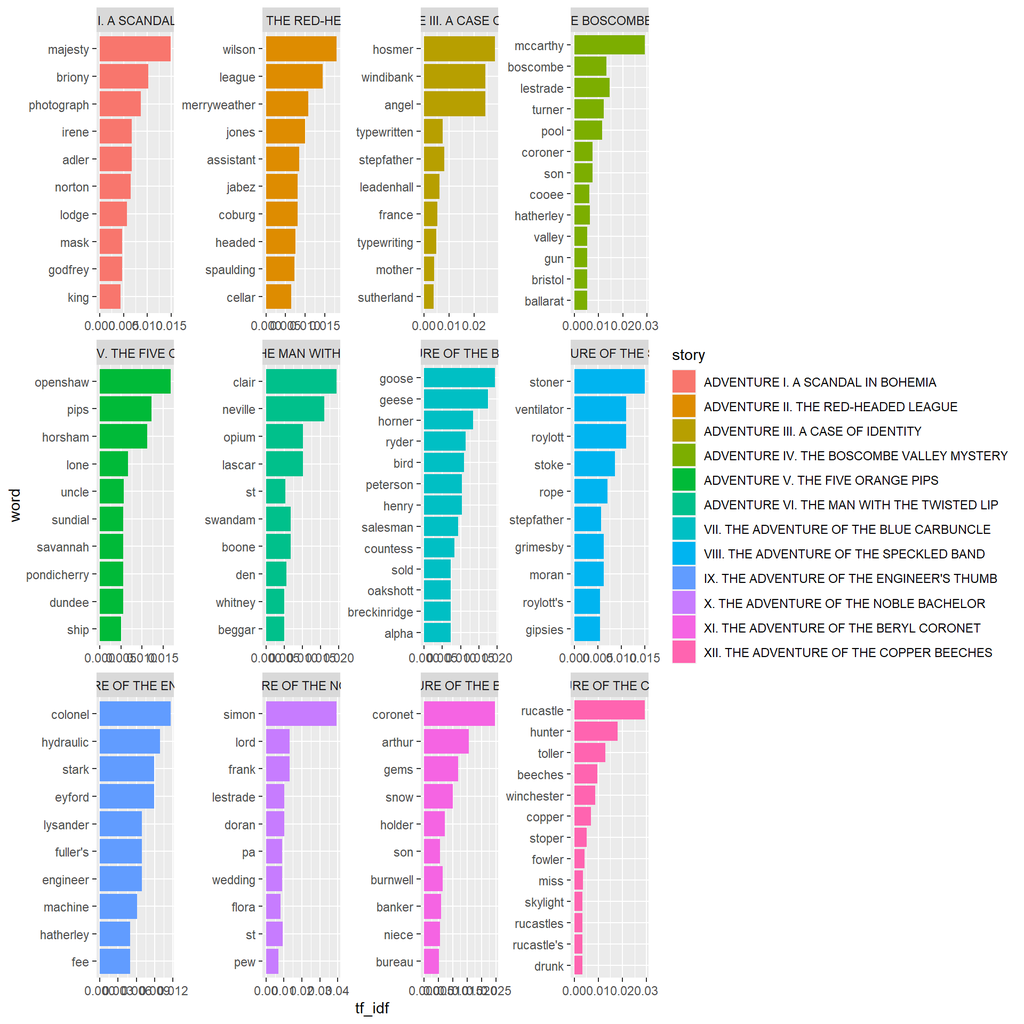

```r
tidy_sherlock %>%
  count(story, word, sort = TRUE) %>%
  bind_tf_idf(word, story, n) %>%
  group_by(story) %>%
  top_n(10) %>%
  ungroup() %>%
  mutate(word = reorder(word, tf_idf)) %>%
  ggplot(aes(word, tf_idf, fill = story)) +
  geom_col(show.legend = TRUE) +
  facet_wrap(~story, scales = "free") +
  coord_flip()
```

### Topic modeling implementation

structural topic model, em algorithm, k will vary by document, slightly computationally intensive

on k :The most important user input in parametric topic models is the number of topics. There is no right answer to the appropriate number of topics. More topics will give more fine-grained representations of the data at the potential cost of being less precisely estimated." - documentation for stm

```
## Beginning Spectral Initialization
##   Calculating the gram matrix...
##   Finding anchor words...
##      ......
##   Recovering initialization...
##      ..........................................................................
## Initialization complete.
## ............
## Completed E-Step (0 seconds).
## Completed M-Step.
## Completing Iteration 1 (approx. per word bound = -7.732)
## ............
## Completed E-Step (0 seconds).
## Completed M-Step.
## Completing Iteration 2 (approx. per word bound = -7.529, relative change = 2.623e-02)
## ............
## Completed E-Step (0 seconds).
## Completed M-Step.
## Completing Iteration 3 (approx. per word bound = -7.443, relative change = 1.142e-02)
## ............
## Completed E-Step (0 seconds).
## Completed M-Step.
## Completing Iteration 4 (approx. per word bound = -7.419, relative change = 3.192e-03)
## ............
## Completed E-Step (0 seconds).
## Completed M-Step.
## Completing Iteration 5 (approx. per word bound = -7.412, relative change = 1.005e-03)
## Topic 1: st, simon, lord, day, lady
##  Topic 2: hat, goose, stone, bird, geese
##  Topic 3: street, matter, hosmer, woman, photograph
##  Topic 4: father, mccarthy, time, son, hand
##  Topic 5: door, miss, house, night, heard
##  Topic 6: time, door, red, business, heard
## ............
## Completed E-Step (0 seconds).
## Completed M-Step.
## Completing Iteration 6 (approx. per word bound = -7.411, relative change = 1.362e-04)
## ............
## Completed E-Step (0 seconds).
## Completed M-Step.
## Model Converged
```

### Plot the beta and gamma matrices

Which words contribute the most to each topic? How much does each topic contribute to a given document? How likely is this document to belong to this topic?

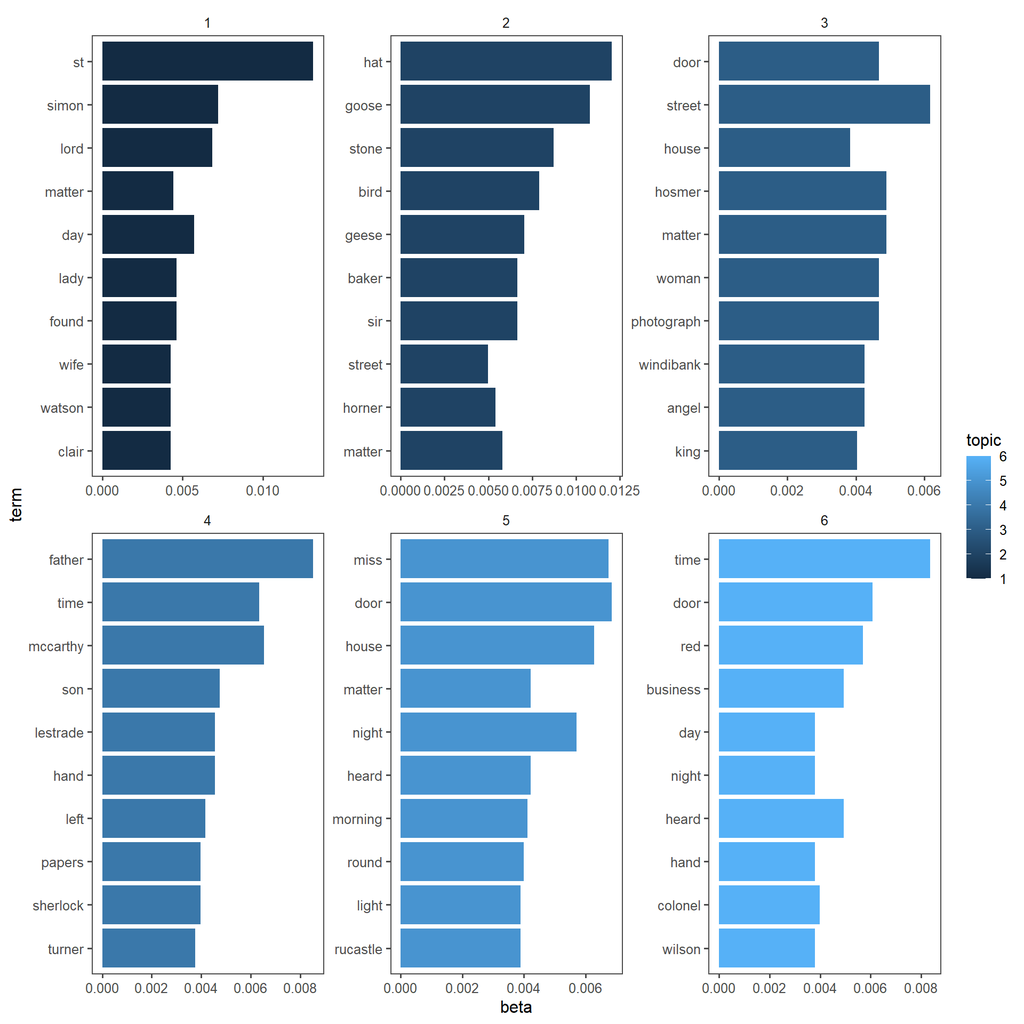

```r
td_beta <- tidy(topic_mod)

td_beta %>%
  group_by(topic) %>%
  top_n(10) %>%
  ungroup() %>%
  mutate(term = reorder(term, beta)) %>%
  ggplot(aes(term, beta, fill = topic)) +
  geom_col(show.legend = TRUE) +
  facet_wrap(~topic, scales = "free") +
  coord_flip() +
  theme_few() +
  scale_color_colorblind()
```

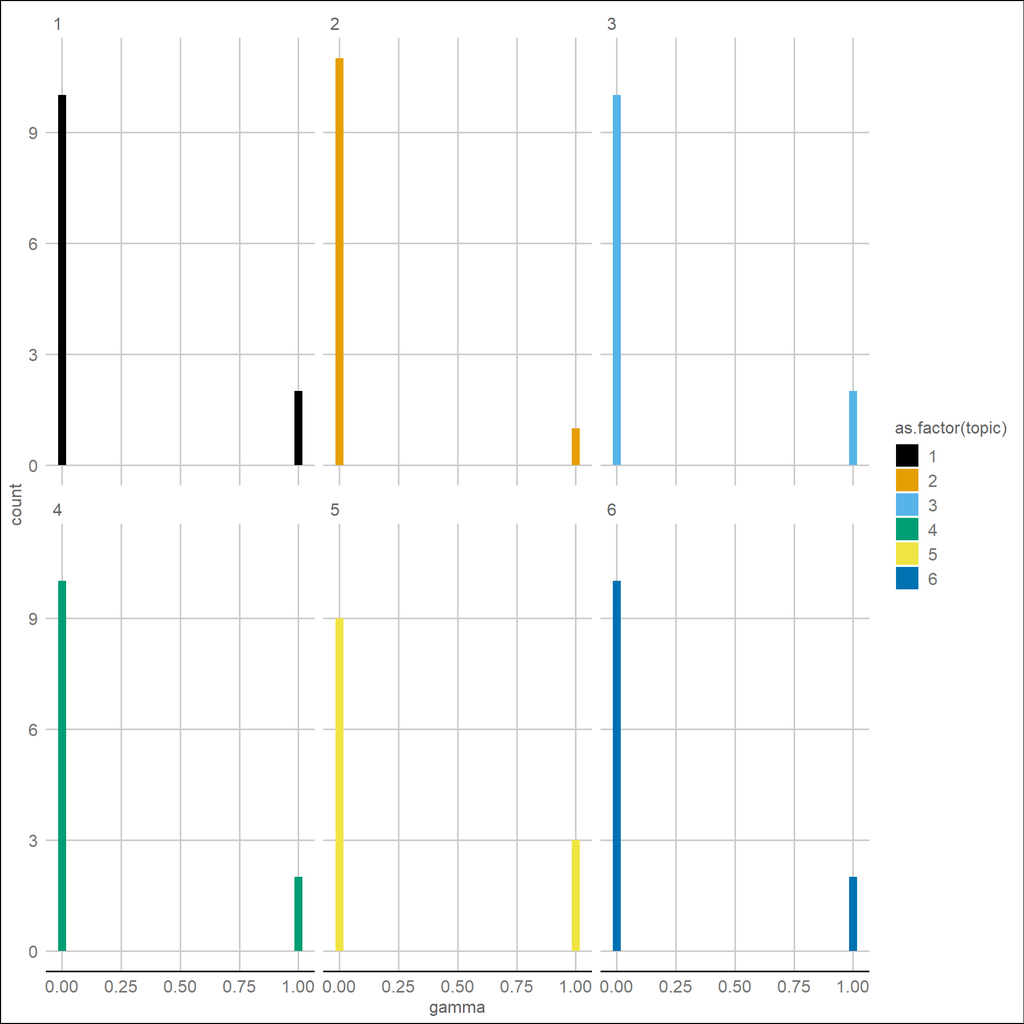

```r
td_gamma <- tidy(topic_mod,
  matrix = "gamma",
  document_names = rownames(sherlock_dfm)
)


td_gamma %>%
  ggplot(aes(gamma, fill = as.factor(topic))) +
  geom_histogram(show.legend = TRUE) +
  facet_wrap(~topic, ncol = 3) +
  theme_gdocs() +
  scale_fill_colorblind()
```

### Trying on my own with Mihai Eminescu’s “Poems”

```r
poezii_raw <- gutenberg_download(35323)
```

### Data prep

- Only taking first half of poems of the raw corpus for better visualization
- Removed editors note, table of contents,
- Used poem titles
- Pulled out Romanian stopwords, the word “poems”, notes, numbers

```r
poezii <- poezii_raw[151:12887, ] %>%
  mutate(poem = ifelse(str_detect(text, "[:upper:]+$"), text, NA)) %>%
  fill(poem) %>%
  mutate(poem = factor(poem, levels = unique(poem)))

stop_snow <- as.data.frame(stopwords("ro", source = "snowball")) %>%
  rename(word = `stopwords("ro", source = "snowball")`)
stop_nltk <- as.data.frame(stopwords("ro", source = "nltk")) %>%
  rename(word = `stopwords("ro", source = "nltk")`)
stop_iso <- as.data.frame(stopwords("ro", source = "stopwords-iso")) %>%
  rename(word = `stopwords("ro", source = "stopwords-iso")`)
numbers <- c(
  "I", "    II", "III", "IV", "V", "VI",
  "VII", "VIII", "11", "1652", "38", "5", "6", "9"
)

stopwords_ro <- left_join(stop_iso, stop_nltk, by = "word") %>%
  left_join(stop_snow, by = "word")

tidy_poezii <- poezii %>%
  mutate(line = row_number()) %>%
  unnest_tokens(word, text) %>%
  anti_join(stopwords_ro) %>%
  filter(word != "poezii") %>%
  filter(!word %in% numbers) %>%
  filter(!poem %in% numbers) %>%
  filter(poem != "NOTE")
tidy_poezii %>%
  count(word, sort = TRUE)
```

```
## # A tibble: 10,038 x 2
##    word      n
##    <chr> <int>
##  1 ochii   178
##  2 lume    175
##  3 dulce   167
##  4 viata   162
##  5 caci    146
##  6 stele   141
##  7 aur     140
##  8 lumea   131
##  9 luna    130
## 10 umbra   129
## # ... with 10,028 more rows
```

“Eyes”, World“,”Sweet“, and”Life" top the list of most frequently occuring words, sounds like poetry!

### Explore tf-idf

Which words are most important?

```r
poezii_tf_idf <- tidy_poezii %>%
  count(poem, word, sort = TRUE) %>%
  arrange(poem, word, n) %>%
  slice(1:2583) %>%
  bind_tf_idf(word, poem, n) %>%
  group_by(poem) %>%
  top_n(5) %>%
  ungroup() %>%
  mutate(word = reorder(word, tf_idf))
```

[figure not shown]

```r
poezii_tf_idf %>%
  ggplot(aes(word, tf_idf, fill = poem)) +
  geom_col(alpha = 0.8, show.legend = FALSE) +
  facet_wrap(~poem, scales = "free", ncol = 3) +
  coord_flip() +
  theme(strip.text = element_text(size = 11)) +
  labs(
    x = NULL, y = "tf-idf",
    title = "Highest tf-idf words in 15 of Mihai Eminescu's Poems",
    subtitle = "Individual poems focus on different themes and visual metaphors"
  ) +
  theme_few()
```

“The Grave of Aron Pumunul” lists the 5 most important words as “whispers”, “whispering”, “extinguished”, “follow”, “field”.

“A Ride at Dawn” lists the 5 most important words as “kiss”, “gentle”, “thin”, “cleave”, and “wash”.

“From Abroad” lists the 5 most important words as “date”, “whispered”, “native”, “groan”, and “clouds”.

“In Bucovina” lists the 5 most important words as “Bucovina”, “step”, “hum”, “tremble”, and “pass”.

“The Hope” lists the 5 most important words as “hope” “I want”, “love”, “dearest”, and “you want”.

“The Mysteries of the Night” lists the 5 most important words as “many”, “gentle”(diminutive), “sighing”, “Cantu”, and “two”.

“What I Wish From You, Beloved Romania” lists the 5 most important words as “Romania” “I wish”, “for you”, “glory”, and “strength”.

“The Heliad” lists the 5 most important words as “garland”, “sylphs”, “heliads”, “cloud”, and “curls”.

“The Artist” lists the 5 most important words as “take”, part of the word “coming true”, “embodied”, “flower”, and “deify”.

“The Love of a Marble” lists the 5 most important words as “I love” “your”, “ocean”, “love”, and “tell”.

“Junii Corupti”* lists the 5 most important words as “forget”, “dry”, “death” or “dying”, “arise”, and “strength”.

“At the Death of Prince Stirbey” lists the 5 most important words as “move”, “Stirbey”, “light”, “to see”, and “hearts”.

“Venus and Madonna” lists the 5 most important words as “women”, “lost”, “Madonna”, “saw”, and “demon”.

“The Epigones” lists the 5 most important words as “gold”, “holy”, “all”, “sense”, and “death”.

“Guardian Angel” lists the 5 most important words as “across”, “you are”, “eyelashes”, “keep watch”, and “guard”.

*the best translation of this title I can think of would be something like “The Corrupted” but this loses the fact that he’s speaking specifically about young people, suggestions appreciated!

### Topic modeling implementation

*set up our dfm*

```r
poezii_dfm <- tidy_poezii %>%
  count(poem, word, sort = TRUE) %>%
  cast_dfm(poem, word, n)
```

*evaluate which k is the best fit for this corpus*

Julia knew that a k of 6 was a good choice for her data but since I don’t know what would be the best fit for this data, let’s find out.

This section adapted from Julia’s post [“Training, evaluating, and interpreting topic models”](https://juliasilge.com/blog/evaluating-stm/)

### Visualize fit metrics

[figure not shown]

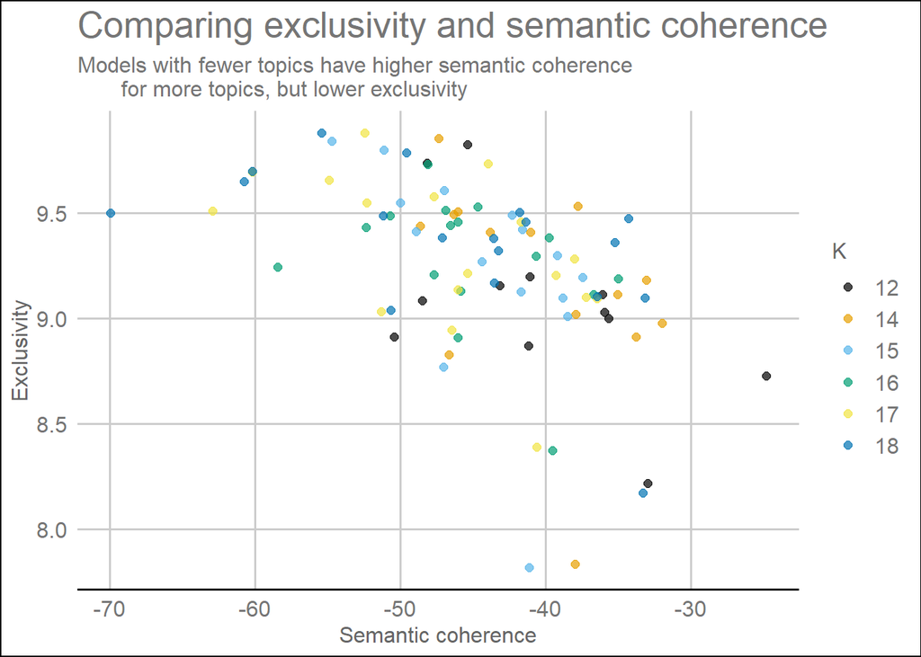

### Plot results

*Beta*

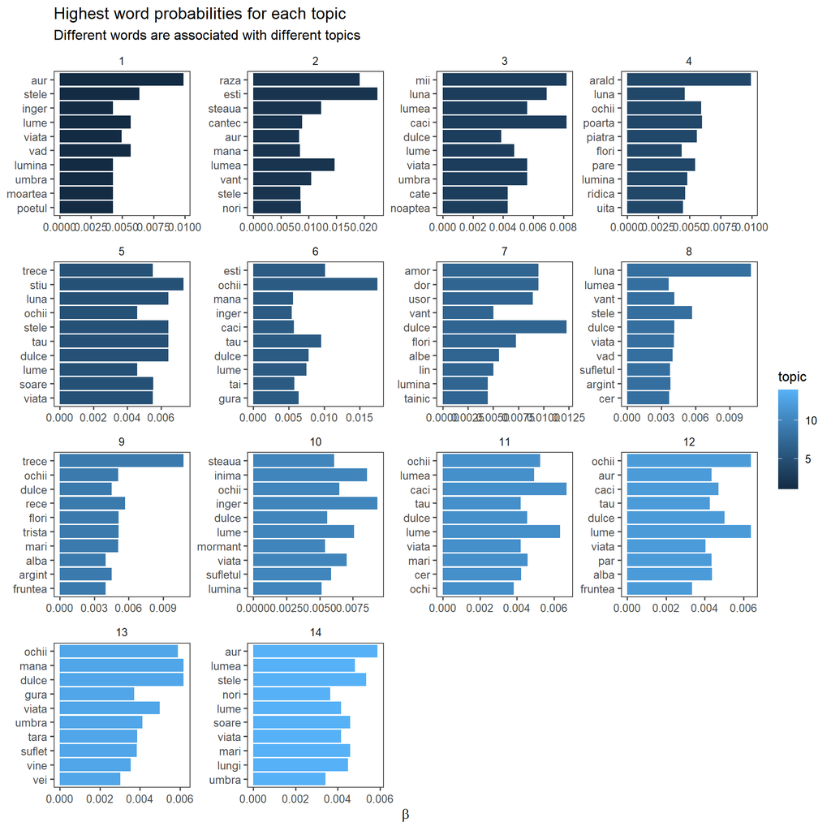

```r
poezii_mod <- k_result %>%
  filter(K == 14) %>%
  pull(topic_model) %>%
  .[[1]]

td_beta_p <- tidy(poezii_mod)

td_beta_p %>%
  group_by(topic) %>%
  top_n(10) %>%
  ungroup() %>%
  mutate(term = reorder(term, beta)) %>%
  ggplot(aes(term, beta, fill = topic)) +
  geom_col(show.legend = TRUE) +
  facet_wrap(~topic, scales = "free") +
  coord_flip() +
  scale_x_reordered() +
  labs(
    x = NULL, y = expression(beta),
    title = "Highest word probabilities for each topic",
    subtitle = "Different words are associated with different topics"
  ) +
  theme_few() +
  scale_color_colorblind()
```

Many of the topics have overlapping words like “sweet”, “stars”, “gold”, “moon”, “eyes”, “world”, “your”, “life”, “light” etc… again, sounds like poetry!

*Gamma*

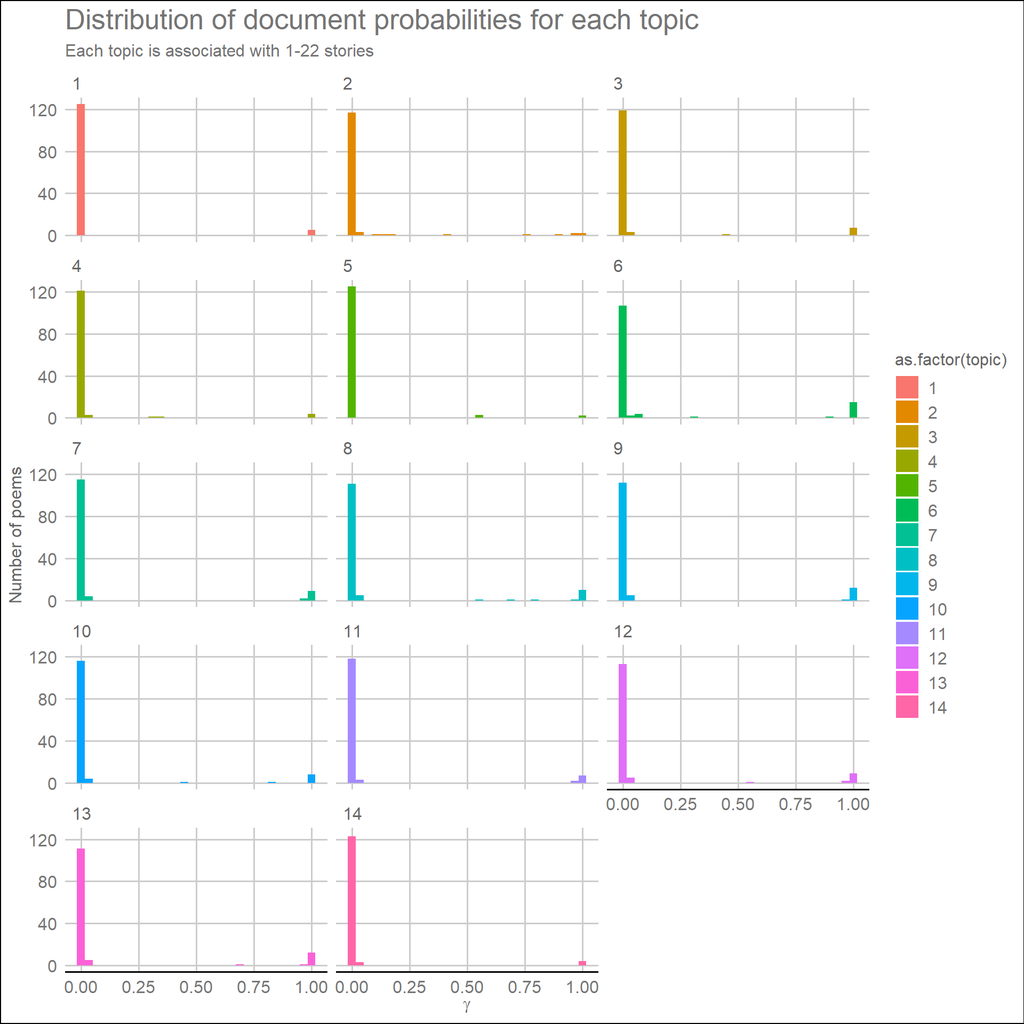

```r
td_gamma_p <- tidy(poezii_mod,
  matrix = "gamma",
  document_names = rownames(poezii_dfm)
)

td_gamma_p %>%
  ggplot(aes(gamma, fill = as.factor(topic))) +
  geom_histogram(show.legend = TRUE) +
  facet_wrap(~topic, ncol = 3) +
  labs(
    title = "Distribution of document probabilities for each topic",
    subtitle = "Each topic is associated with 1-22 stories",
    y = "Number of poems", x = expression(gamma)
  ) +
  theme_gdocs() +
  scale_color_colorblind()
```

[figure not shown]

```r
top_terms <- td_beta_p %>%
  arrange(beta) %>%
  group_by(topic) %>%
  top_n(7, beta) %>%
  arrange(-beta) %>%
  select(topic, term) %>%
  summarise(terms = list(term), .groups = "keep") %>%
  mutate(terms = map(terms, paste, collapse = ", ")) %>%
  unnest(cols = c(topic, terms))

gamma_terms <- td_gamma_p %>%
  group_by(topic) %>%
  summarise(gamma = mean(gamma), .groups = "keep") %>%
  arrange(desc(gamma)) %>%
  left_join(top_terms, by = "topic") %>%
  mutate(
    topic = paste0("Topic ", topic),
    topic = reorder(topic, gamma)
  )

gamma_terms %>%
  top_n(7, gamma) %>%
  ggplot(aes(topic, gamma, label = terms, fill = topic)) +
  geom_col(show.legend = FALSE) +
  geom_text(hjust = 0, nudge_y = 0.0005, size = 3) +
  coord_flip() +
  scale_y_continuous(
    expand = c(0, 0),
    limits = c(0, 0.2),
    labels = percent_format()
  ) +
  labs(
    x = NULL, y = expression(gamma),
    title = "7 topics by prevalence in the Poems corpus",
    subtitle = "With the top words that contribute to each topic"
  ) +
  theme_few() +
  scale_color_colorblind() +
  theme(
    plot.title = element_text(size = 14),
    plot.subtitle = element_text(size = 12))
```

```r
gamma_terms %>%
  select(topic, gamma, terms) %>%
  kable(
    digits = 3,
    col.names = c("Topic", "Expected topic proportion", "Top 7 terms")
  )
```

| Topic | Expected topic proportion | Top 7 terms |
| --- | --- | --- |
| Topic 6 | 0.127 | ochii, esti, tau, dulce, lume, gura, tai |
| Topic 13 | 0.107 | mana, dulce, ochii, viata, umbra, tara, suflet |
| Topic 8 | 0.102 | luna, stele, dulce, vant, viata, vad, argint |
| Topic 9 | 0.101 | trece, rece, trista, flori, ochii, mari, argint |
| Topic 12 | 0.090 | ochii, lume, dulce, caci, alba, aur, par |
| Topic 7 | 0.086 | dulce, amor, dor, usor, flori, albe, lin |
| Topic 10 | 0.072 | inger, inima, lume, viata, ochii, steaua, sufletul |
| Topic 11 | 0.070 | caci, lume, ochii, lumea, mari, dulce, cer |
| Topic 3 | 0.058 | mii, caci, luna, lumea, umbra, viata, lume |
| Topic 2 | 0.051 | esti, raza, lumea, steaua, vant, cantec, nori |
| Topic 1 | 0.039 | aur, stele, vad, lume, viata, moartea, inger |
| Topic 4 | 0.037 | arald, poarta, ochii, piatra, pare, lumina, ridica |
| Topic 14 | 0.032 | aur, stele, lumea, soare, mari, lungi, lume |
| Topic 5 | 0.029 | stiu, tau, luna, stele, dulce, soare, trece |

Topic 8 includes words related to night time like “moon”, “stars”, and “silver”.

Many of the topics seem to have grouped words which end in similar ways. Romanian uses word endings to denote concepts like ownership “my”, “your”, “ours”, plurality similar to the English ending “-s”, or articles like “a” or “the” so in this case stemming may be a good choice. Might want to come back to this and try stemming but I’m conflicted since I know it can often hurt.

I’m not sure how much this type of modeling told me about the text but I imagine if I had a huge corpus of text that covered a wide variety of topics then this might be more informative. It definitely confirms my impression of Eminescu as being a very sentimental, romantic poet. Maybe a sentiment analysis would be a good idea for his works?

This was a really fun exercise in topic modeling and I’m grateful to Julia Silge for her super informative blog!